# Coretan C2

Ahmad Husain Abdullah

2019-02-27

# Naive Bayes

## Law of Probability

Probabilitas dua buah peristiwa terjadi.

Independent Event: Kejadian saling bebas. Artinya, kemungkinan terjadi A tidak dipengaruhi oleh kejadian B.  
- Cuaca cerah dan tim sepak bola memenangkan pertandingan berikutnya. - Kemungkinan Arsenal menang, dan Persija Jakarta Menang. - Perusahaan merekrut office boy baru, Perusahaan menaikkan gaji karyawan.

Dependent Event: Kejadian saling terikat. Artinya, kemungkinan terjadi A dipengaruhi oleh kejadian B.  
. - Mesut Ozil main, Arsenal memenangkan pertandingan. - Cuaca cerah, Wisatawan berjemur di pantai.

Diskusi:

Event 1: Perusahaan mengalami downsizing (pengurangan jumlah karyawan) lebih dari 50% (2% kemungkinannya) Event 2: Deklarasi kebangkrutan (3% kemungkinan)

Contoh diatas adalah peristiwa dependent.

Event 1: Perusahaan merekrut manajer sales baru. (30% kemungkinan) Event 2: Perusahaan memperkejakan akuntan tambahan. (40% kemungkinan)

Contoh diatas adalah peristiwa independent.

Diskusi:

1. Untuk menghitung probabilitas kedua buah peristiwa independent terjadi bersamaan, kita dapat menggunakan rumus $P(A \cap B) = P(A) . P(B)$. Berarti jika ditanya probabilitas Perusahaan merekrut manajer sales baru, dan memperkejakan akuntan tambahan di tahunn depan secara bersamaan adalah $0.3 * 0.4 = 0.12$
2. Untuk kasus peristiwa dependent, kita tidak dapat menggunakan konsep perkalian untuk menghitung probabilitasnya. Untuk menghitung probabilitasnya kita harus menggunakan konsep bayes. Dimana kita harus memperhitungkan peluang gabungan kedua peristiwa dependent terjadi (joint probability).

## Conditional Probability Bayes’s Theorem

Rumus peluang bersyarat:

$P(A|B)=\frac{P(A \cap B)}{P(B)}$

Dimana:  
$P(A \cap B)$ = Seberapa sering peristiwa A dan B terjadi bersamaan. $P(B)$ = seberapa sering peristiwa B terjadi secara general.

Rumus diatas akan di transformasi menjadi:

$P(A|B)= \frac{P(B|A)*P(A)}{P(B)}$

Studi Kasus:  
Deteksi email spam diketahui: Saya mempunyai 500 email, 100 email tersebut adalah spam. dari 500 email tersebut 5 email mengandung kata “lottery”. dan 4 email diantaranya adalah spam.

N = 500  
P(spam) = 100/500 = 0.2  
P(ham) = 400/500 = 0.8  
P(lottery) = 5/500 = 0.01  
P(lottery|spam) = 4/100 = 0.04  
P(lottery|ham) = 1/400 = 0.0025

*Prior Probability* : Dari contoh spam deteksi diatas, misal kita tidak mengetahui konten email nya apakah mengandung “lottery” atau tidak. Bagaimana kita mengestimasi kemungkinan terjadi spam pada email kita? Kita akan bilang sekitar 20%. $P(spam) = \frac{100}{500} = 0.2$.

*Prior Probability* : Probabilitas sebuah peristiwa (spam) terjadi sebelum diberikan beberapa syarat lain (given conditional probabilty).

*Likelihood* : Dari contoh spam deteksi diatas, saya ingin tahu dari data historis, probabilitas kata “lottery” muncul dengan syarat (given) bahwa dia itu spam adalah $P(lottery|spam) = \frac{4}{100} = 0.04$. Berarti saya bisa bilang, dari data historis email saya, probabilitas muncul “Lottery” dengan syarat dia masuk spam adalah sebesar 4%.

*Marginal Probability* : Probabilitas kata “lottery” muncul di seluruh email adalah. $P(lottery)=P(lottery|Spam) * P(spam) + P(lottery|ham) * P(ham)$ maka akan diperoleh hasil $(\frac{4}{100}*\frac{100}{500}) + (\frac{1}{400}*\frac{400}{500}) = \frac{5}{500} = 0.01$. Berarti dikasus ini saya bisa bilang probabilitas muncul kata “lottery” di seluruh email adalah 1%.

*Marginal Probability* : Probabilitas sebuah syarat peristiwa muncul secara general.

## Characteristic Naive Bayes

1. Mengasumsikan semua atribut pada dataset itu sama pentingnya dan independen.
2. Skewness due to data scarcity misal saya punya 1 email yang mengandung kata “prince” dan email tersebut adalah spam. maka kalau ada email lain yg mengandung kata “prince” email tersebut akan otomatis masuk spam.

## Bayes Theorem Application: Customer Churn

400 customers  
40 churned, 360 tidak  
6 dari 40 customers yg churned menggunakan kata “terrible” pada surat pernyataan  
2 dari 360 customers yg tidak churned menggunakan kata “terrible” pada surat pernyataan

P(Churn| Terrible) = P(Terrible | Churn) * P(Churn) / P(Terrible) = 6/40 * 40/400 / 8/400 = 0.15 * 0.1 / 0.02 = 0.75

1000 customers  
250 of 1000 churned; 750 of them did not  
45 of the 250 churned customers use the word “terrible” (t) in their last correspondence; While only 11 of the 750 stayed customer used it  
5 of the 250 churned customers use the word “recommended” (r)in their last correspondence; While 155 of the 750 stayed customer used it  
85 of the 250 churned customers sent the email during the 23:59 to 06:00 period (m); While 156 of the 750 stayed customer sent it inside that period

misal ada seorang customers bernama Husain pada correspondance terakhirnya dia menggunakan kata terrible, tidak menggunakan kata recommended dan mengirim email pada pukul 16:40

berapa peluang husain akan churn?

## Laplace Estimator

permasalahan dari naive bayes adalah ketika kita mendapatkan 0 kejadian pada suatu kelas yang dapat membuat nilai peluang kita menjadi 0 pada kelas tersebut. ada beberapa pendekatan yang bisa kita lakukan seperti

1. Menghapus variabel yang mengandung 0  
   Resiko: kita kehilangan bayak informasi, karena kita harus remove 1 variable
2. mengabaikan variabel yang mengandung 0  
   Resiko : peluang suatu kelas akan menjadi 0 terus
3. menambahkan nilai kecil (1) untuk setiap kejadian. (terbaik)

Fungsi dari lapcate estimator ini untuk menghindari nilai 0.

## Spam Classifier

```r
sms <- read.csv("data_input/spam.csv", stringsAsFactors = FALSE, encoding = "UTF-8")
str(sms)
```

```
## 'data.frame':    5572 obs. of  5 variables:
##  $ v1 : chr  "ham" "ham" "spam" "ham" ...
##  $ v2 : chr  "Go until jurong point, crazy.. Available only in bugis n great world la e buffet... Cine there got amore wat..." "Ok lar... Joking wif u oni..." "Free entry in 2 a wkly comp to win FA Cup final tkts 21st May 2005. Text FA to 87121 to receive entry question("| __truncated__ "U dun sa…
##  $ X  : chr  "" "" "" "" ...
##  $ X.1: chr  "" "" "" "" ...
##  $ X.2: chr  "" "" "" "" ...
```

```r
set.seed(100)
library(dplyr)
sms <- sms %>%
  select("label" = v1, "text" = v2) %>%
  mutate("label" = as.factor(label))

sms[sample(nrow(sms), 10),"text"]
```

```
##  [1] "Yeah I don't see why not"
##  [2] "Dad went out oredi... "
##  [3] "There is no sense in my foot and penis."
##  [4] "Hi the way I was with u 2day, is the normal way&this is the real me. UR unique&I hope I know u 4 the rest of mylife. Hope u find wot was lost."
##  [5] "Hello madam how are you ?"
##  [6] "All these nice new shirts and the only thing I can wear them to is nudist themed ;_; you in mu?"
##  [7] "DO U WANT 2 MEET UP 2MORRO"
##  [8] "I did. One slice and one breadstick. Lol"
##  [9] "Slaaaaave ! Where are you ? Must I summon you to me all the time now ? Don't you wish to come to me on your own anymore?"
## [10] "Hey i booked the kb on sat already... what other lessons are we going for ah? Keep your sat night free we need to meet and confirm our lodging "
```

Text mining dengan packagase `tm`:

1. Read dataset
2. Convert data teks ke bentuk corpus.
3. Pra-proses data teks.
   - tolower
   - remove tanda baca
   - remove angka
4. Stemming. (Transformasi teks ke bentuk kata dasar)
5. Tokenization (Document Term Matrix)
6. Creat Model
7. Evaluasi

```r
library(tm)
# VCorpus requires a source object, which can be created using VectorSource
sms.corpus <- VCorpus(VectorSource(sms$text))
# Inspecting the first 2 items in our corpus:
sms.corpus[[1]]$content
```

```
## [1] "Go until jurong point, crazy.. Available only in bugis n great world la e buffet... Cine there got amore wat..."
```

```r
sms.corpus[[2]]$content
```

```
## [1] "Ok lar... Joking wif u oni..."
```

```r
 # convert all text to lower so YES == yes == Yes
sms.corpus <- tm_map(sms.corpus, content_transformer(tolower))
# Create a custom transformer to substitute punctuations with a space " "
transformer <- content_transformer(function(x, pattern) {
    gsub(pattern, " ", x)
})

# Remove numbers, stopwords ("am", "and", "or", "if")
sms.corpus <- tm_map(sms.corpus, removeNumbers)
sms.corpus <- tm_map(sms.corpus, removeWords, stopwords("english"))

# Substitute ".", "/", "@" and common punctuations with a white space
sms.corpus<- tm_map(sms.corpus, transformer, "/")
sms.corpus <- tm_map(sms.corpus, transformer, "@")
sms.corpus <- tm_map(sms.corpus, transformer, "-")
sms.corpus <- tm_map(sms.corpus, transformer, "\\.")

# For all other punctuations, simply strip them using the built-in function
sms.corpus.new <- tm_map(sms.corpus, removePunctuation)
```

```r
# see how stemming works
library(SnowballC)
wordStem(c("do", "doing", "kiss", "kisses", "kissing"))
```

```
## [1] "do"   "do"   "kiss" "kiss" "kiss"
```

```r
sms.corpus.new <- tm_map(sms.corpus.new, stemDocument)
sms.corpus.new <- tm_map(sms.corpus.new, stripWhitespace)
```

```r
sms.dtm <- DocumentTermMatrix(sms.corpus.new)
#Examine our dtm
inspect(sms.dtm)
```

```
## <<DocumentTermMatrix (documents: 5572, terms: 6183)>>
## Non-/sparse entries: 42895/34408781
## Sparsity           : 100%
## Maximal term length: 38
## Weighting          : term frequency (tf)
## Sample             :
##       Terms
## Docs   call can come day free get just ltgt now will
##   1085    0   0    1   2    0   1    0    0   0   12
##   1579    0   0    0   0    0   0    0   18   0    0
##   1863    0   0    0   0    0   0    0    0   0    0
##   2158    0   0    0   0    0   0    0    0   0    0
##   2370    0   0    0   0    1   0    0    0   0    0
##   2380    0   1    0   1    0   0    0    1   0    0
##   2434    0   3    0   0    1   1    0    6   0    0
##   2848    0   0    0   0    0   0    0    0   0    0
##   3016    0   0    0   6    0   0    0    2   0    0
##   5105    0   0    0   0    1   0    0    0   0    0
```

```r
findFreqTerms(sms.dtm, 300)
```

```
## [1] "call" "can"  "come" "get"  "just" "now"  "will"
```

```r
set.seed(100)
split_75 <- sample(nrow(sms.dtm), nrow(sms.dtm)*0.75)
sms_train <- sms.dtm[split_75, ]
sms_test <- sms.dtm[-split_75, ]
```

```r
train_labels <- sms[split_75, 1]
test_labels <- sms[-split_75, 1]
```

```r
prop.table(table(train_labels))
```

```
## train_labels
##       ham      spam
## 0.8631251 0.1368749
```

```r
prop.table(table(test_labels))
```

```
## test_labels
##       ham      spam
## 0.8743719 0.1256281
```

```r
set.seed(100)
sms_freq <- findFreqTerms(sms.dtm, 20)
# take a look at some of the words that will be used as predictors in our classifier:
sms_freq[sample(length(sms_freq), 10)]
```

```
##  [1] "get"     "eve"     "msg"     "babe"    "listen"  "lor"     "speak"
##  [8] "hear"    "mom"     "content"
```

```r
sms_train <- sms_train[,sms_freq]
sms_test <- sms_test[,sms_freq]
```

```r
# Takes an input, "x" and assign x to a 1 or 0
bernoulli_conv <- function(x){
        x <- as.factor(as.numeric(x > 0))
}
```

```r
train_bn <- apply(sms_train, 2, bernoulli_conv)
test_bn <- apply(sms_test, 2, bernoulli_conv)
```

```r
set.seed(100)
train_bn[1:6,sample(ncol(train_bn), 10)]
```

```
##       Terms
##        get eve msg babe listen lor speak hear mom content
##   [1,] "0" "0" "0" "0"  "0"    "0" "0"   "0"  "0" "0"
##   [2,] "0" "0" "0" "0"  "0"    "0" "0"   "0"  "0" "0"
##   [3,] "0" "0" "0" "0"  "0"    "0" "0"   "0"  "0" "0"
##   [4,] "0" "0" "0" "0"  "0"    "0" "0"   "0"  "0" "0"
##   [5,] "0" "0" "0" "0"  "0"    "0" "0"   "0"  "0" "0"
##   [6,] "0" "0" "0" "0"  "0"    "0" "0"   "0"  "0" "0"
```

```r
head(train_bn[train_bn[,4] == "1" | train_bn[,5] == "1", 1:7])
```

```
##       Terms
##        abl abt account actual address afternoon age
##   [1,] "0" "0" "0"     "0"    "1"     "0"       "0"
##   [2,] "0" "0" "0"     "1"    "0"     "0"       "0"
##   [3,] "0" "0" "0"     "1"    "0"     "0"       "0"
##   [4,] "0" "0" "0"     "0"    "1"     "0"       "0"
##   [5,] "0" "0" "1"     "0"    "1"     "0"       "0"
##   [6,] "0" "0" "0"     "0"    "1"     "0"       "0"
```

```r
ncol(sms_train);ncol(sms_test)
```

```
## [1] 449
```

```
## [1] 449
```

```r
sum(dimnames(sms_train)$Terms == dimnames(sms_test)$Terms)
```

```
## [1] 449
```

```r
num_train <- colSums(apply(train_bn, 2, as.numeric))
num_test <- colSums(apply(test_bn, 2, as.numeric))

num_train[num_train < 3]
```

```
## named numeric(0)
```

```r
num_test[num_test < 3]
```

```
##    address   deliveri friendship        haf       hand     murder
##          2          2          1          1          1          1
##      price        sad       wife
##          2          1          2
```

```r
library(e1071)
```

```r
spam_model <- naiveBayes(train_bn, train_labels, laplace = 1)
```

```r
spam_prediction <- predict(spam_model, test_bn)
```

```r
table(prediction = spam_prediction, actual=test_labels)
```

```
##           actual
## prediction  ham spam
##       ham  1213   26
##       spam    5  149
```

```r
sum(spam_prediction == test_labels)/length(test_labels)*100
```

```
## [1] 97.77459
```

```r
inspect(sms_test[test_labels == "ham" & spam_prediction != test_labels,])
```

```
## <<DocumentTermMatrix (documents: 5, terms: 449)>>
## Non-/sparse entries: 40/2205
## Sparsity           : 98%
## Maximal term length: 11
## Weighting          : term frequency (tf)
## Sample             :
##       Terms
## Docs   address alway call com free get may mobil now send
##   1497       0     1    0   0    0   2   1     1   1    2
##   1506       0     0    0   0    1   0   0     0   0    0
##   2379       0     0    0   2    1   0   0     1   0    1
##   4801       1     0    2   0    0   1   2     0   1    0
##   5168       0     0    0   0    0   0   0     0   0    0
```

```r
sms[c(1497, 1506, 2379, 4801, 5168),2]
```

```
## [1] "I'm always on yahoo messenger now. Just send the message to me and i.ll get it you may have to send it in the mobile mode sha but i.ll get it. And will reply."
## [2] "Total video converter free download type this in google search:)"
## [3] "Hi, Mobile no.  &lt;#&gt;  has added you in their contact list on www.fullonsms.com It s a great place to send free sms to people For more visit fullonsms.com"
## [4] "The guy at the car shop who was flirting with me got my phone number from the paperwork and called and texted me. I'm nervous because of course now he may have my address. Should i call his boss and tell him, knowing this may get him fired?"
## [5] "Oh did you charge camera"
```

### roc

cara lain kita untuk melihat model performence. menggambarkan seberapa besar TP dan FP. Kita bisa lihat sebaik apa luar kurva dibawah nya atau yg biasa disebut dengan AUC.. AUC rangenya dari 0-1.

```r
spam_prediction_raw <- predict(spam_model, test_bn, type = "raw")
head(spam_prediction_raw)
```

```
##               ham         spam
## [1,] 9.794638e-01 2.053623e-02
## [2,] 3.652798e-09 1.000000e+00
## [3,] 9.998786e-01 1.214358e-04
## [4,] 9.993149e-01 6.851457e-04
## [5,] 9.891593e-01 1.084067e-02
## [6,] 9.999851e-01 1.486662e-05
```

```r
predict(spam_model, newdata = test_bn, type = "class", threshold = 0.001) %>%
  head()
```

```
## [1] ham  spam ham  ham  ham  ham
## Levels: ham spam
```

```r
spam_df <- data.frame("prediction"=spam_prediction_raw[,2], "trueclass"=as.numeric(test_labels=="spam"))
head(spam_df)
```

```
##     prediction trueclass
## 1 2.053623e-02         0
## 2 1.000000e+00         1
## 3 1.214358e-04         0
## 4 6.851457e-04         0
## 5 1.084067e-02         0
## 6 1.486662e-05         0
```

```r
library(ROCR)
```

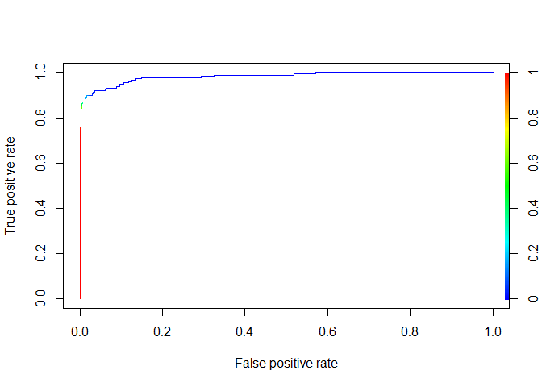

```r
spam_roc <- ROCR::prediction(spam_df$prediction, spam_df$trueclass)
plot(performance(spam_roc, "tpr", "fpr"),colorize = TRUE)
```

```r
auc_value <- performance(spam_roc, measure = "auc")
auc_value@y.values[[1]]
```

```
## [1] 0.982707
```

AUC: Area Under the Curve = 0.98. artinya model sudah cukup baik memprediksi kelas positif dan kelas negatif. Cocok digunakan ketika ada label yang tidak seimbang (unbalance).

```r
prop.table(table(sms$label))
```

```
##
##       ham      spam
## 0.8659368 0.1340632
```

## Predicting votes

```r
votes <- read.csv("data_input/votes.txt")
head(votes)
```

```
##   republican n y n.1 y.1 y.2 y.3 n.2 n.3 n.4 y.4 X. y.5 y.6 y.7 n.5 y.8
## 1 republican n y   n   y   y   y   n   n   n   n  n   y   y   y   n   ?
## 2   democrat ? y   y   ?   y   y   n   n   n   n  y   n   y   y   n   n
## 3   democrat n y   y   n   ?   y   n   n   n   n  y   n   y   n   n   y
## 4   democrat y y   y   n   y   y   n   n   n   n  y   ?   y   y   y   y
## 5   democrat n y   y   n   y   y   n   n   n   n  n   n   y   y   y   y
## 6   democrat n y   n   y   y   y   n   n   n   n  n   n   ?   y   y   y
```

```r
names(votes) <- c("party",
                  "hcapped_infants",
                  "watercost_sharing",
                  "adoption_budget_reso",
                  "physfee_freeze",
                  "elsalvador_aid",
                  "religious_grps",
                  "antisatellite_ban",
                  "nicaraguan_contras",
                  "mxmissile",
                  "immigration",
                  "synfuels_cutback",
                  "education_funding",
                  "superfundright_sue",
                  "crime",
                  "dutyfree_exps",
                  "expadmin_southafr"
                  )
```

```r
table(votes$party, votes$hcapped_infants)
```

```
##
##                ?   n   y
##   democrat     9 102 156
##   republican   3 133  31
```

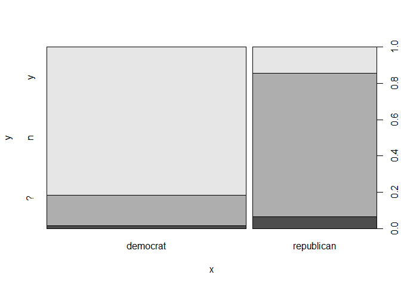

```r
plot(votes$party, votes$nicaraguan_contras)
```

```r
set.seed(100)
split_votes <- sample(nrow(votes), nrow(votes)*0.75)
votes.train <- votes[split_votes, ]
votes.test <- votes[-split_votes, ]
```

```r
votes_model <- naiveBayes(party ~ ., votes.train)
votes_prediction <- predict(votes_model, votes.test)
```

```r
table("prediction"=votes_prediction, "actual"=votes.test$party)
```

```
##             actual
## prediction   democrat republican
##   democrat         60          3
##   republican       13         33
```

```r
sum(votes_prediction == votes.test$party)/length(votes.test$party)
```

```
## [1] 0.853211
```

```r
prop.table(table(votes.train$party))
```

```
##
##   democrat republican
##  0.5969231  0.4030769
```

```r
# Loop over all attribute variables in the dataset (v1, v2 ... vn) and create cross-classifying table against the class variable
# 1st loop: table(hcapped_infants, class)
# 2nd loop: table(watercost_sharing, class)
# ... 17th loop: table(expadmin_southafr, class)

freqtable.votes <- lapply(votes.train[,c(2:17)], table, votes.train[,1])

# freqtable.votes is now a List of 9 tables.
# each table has variable v as row, and one column for each of the class variable (possible outcome)

freqtable.bc <- lapply(freqtable.votes, t)
freqtable.bc$hcapped_infants
```

```
##
##                ?   n   y
##   democrat     5  72 117
##   republican   2 106  23
```

```r
paste("A-Priori Probabiltiies:")
```

```
## [1] "A-Priori Probabiltiies:"
```

# Decision Tree

Pada proses bisnis, decision tree salah satu model yg paling sering digunakan, karna model nya itu mudah diinterpretasikan untuk orang yg non teknis, jadi setelah model ini jadi, dia itu membuatkan sebuah step of rules. jadi konsep di decision tree ingin mencarikan rules apa aja yang kalo misal kita tanyakan ke data kita bisa memotong motong dan membuat data kita jadi homogen.

## Entropy and Information Gain

Cara pemilihan variabel yang dijadikan sebagai inner nodes adalah menggunakan acuan entropy dan information gain.

1. Entropy: mengukur seberapa homogen data kita (range 0<x<1)
2. Information Gain: entropy total - entropy tiap variabel.

```r
library(partykit)
```

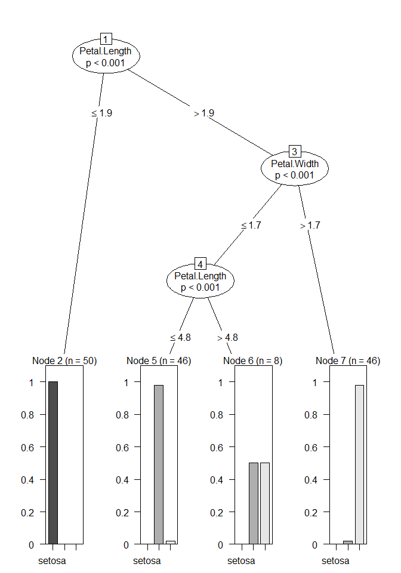

```r
species <- ctree(Species ~ ., iris)
plot(species)
```

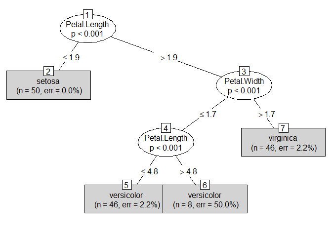

```r
plot(species, type="simple")
```

PLot diatas mudah diinterpretasikan: 1. Rulesnya adalah, jika saya memiliki data baru dengan ukuran panjang kelopak (petal) <= 1.9 maka model saya prediksi sebagai setosa. 2. error adalah tingkat kesalahan model memprediksi terhadap data train.

```r
predict(species, newdata = data.frame(Petal.Length = 1, Sepal.Length = 5, Sepal.Width = 3, Petal.Width = 2.2))
```

```
##      1
## setosa
## Levels: setosa versicolor virginica
```

```r
diabetes <- read.csv("data_input/diabetes.csv")
head(diabetes)
```

```
##   pregnant glucose pressure triceps insulin mass pedigree age diabetes
## 1        6     148       72      35       0 33.6    0.627  50      pos
## 2        1      85       66      29       0 26.6    0.351  31      neg
## 3        8     183       64       0       0 23.3    0.672  32      pos
## 4        1      89       66      23      94 28.1    0.167  21      neg
## 5        0     137       40      35     168 43.1    2.288  33      pos
## 6        5     116       74       0       0 25.6    0.201  30      neg
```

```r
set.seed(100)
in_diabetes_train <- sample(nrow(diabetes), nrow(diabetes)*0.9)
diab_train <- diabetes[in_diabetes_train, ]
diab_test <- diabetes[-in_diabetes_train, ]
```

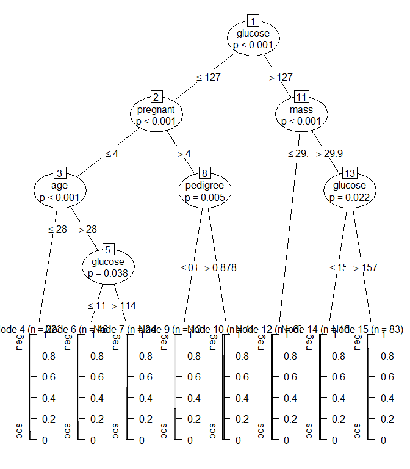

```r
diab_model_def <- ctree(diabetes ~., diab_train)
plot(diab_model_def)
```

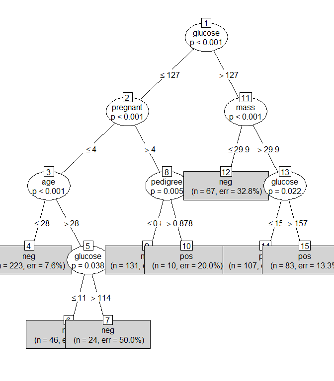

```r
plot(diab_model_def, type="simple")
```

```r
pred_diab_def_train <- predict(diab_model_def, newdata = diab_train)
pred_diab_def_test <- predict(diab_model_def, newdata = diab_test)
```

```r
library(caret)
confusionMatrix(pred_diab_def_train, diab_train[,9])
```

```
## Confusion Matrix and Statistics
##
##           Reference
## Prediction neg pos
##        neg 393  98
##        pos  53 147
##
##                Accuracy : 0.7815
##                  95% CI : (0.7488, 0.8118)
##     No Information Rate : 0.6454
##     P-Value [Acc > NIR] : 5.699e-15
##
##                   Kappa : 0.5019
##  Mcnemar's Test P-Value : 0.0003427
##
##             Sensitivity : 0.8812
##             Specificity : 0.6000
##          Pos Pred Value : 0.8004
##          Neg Pred Value : 0.7350
##              Prevalence : 0.6454
##          Detection Rate : 0.5687
##    Detection Prevalence : 0.7106
##       Balanced Accuracy : 0.7406
##
##        'Positive' Class : neg
##
```

```r
confusionMatrix(pred_diab_def_test, diab_test[,9])
```

```
## Confusion Matrix and Statistics
##
##           Reference
## Prediction neg pos
##        neg  47  11
##        pos   7  12
##
##                Accuracy : 0.7662
##                  95% CI : (0.6559, 0.8552)
##     No Information Rate : 0.7013
##     P-Value [Acc > NIR] : 0.1301
##
##                   Kappa : 0.4127
##  Mcnemar's Test P-Value : 0.4795
##
##             Sensitivity : 0.8704
##             Specificity : 0.5217
##          Pos Pred Value : 0.8103
##          Neg Pred Value : 0.6316
##              Prevalence : 0.7013
##          Detection Rate : 0.6104
##    Detection Prevalence : 0.7532
##       Balanced Accuracy : 0.6961
##
##        'Positive' Class : neg
##
```

Diatas adalah perbandingan performa model terhadap data train dan data test. nilai akurasinya tidak jauh berbeda, artinya model cukup baik memprediksi unseen data (tidak overfit)

## Pruning and Tree-size

Setelah membagi data train dan data test, ketika kita menggunakan decision tree kita harus mengatur kapan pohon tersebut harus berhenti tumbuh. jika pohon itu tumbuh tanpa batas, pohon tersebut akan membelah semua titik dan menghasilkan model yang terlalu spesifik (overfitting: varians nya tinggi, bias nya kecil). Ketika kita memiliki model yang overfitting, maka model kita tidak bisa mempredik unseen data (hanya bisa mempredik data train). Agar tidak overfitting, dengan menetapkan jumlah level untuk memberikan batas kapan pohon yang terbentuk akan berhenti tumbuh. ada dua metode dalam mengatasi overfitting ini, yaitu:

1. prepruning, membatasi pembentukan pohon dari awal.
2. postpruning, yaitu menyederhanakan pohon dengan cara membuang beberapa cabang pohon setelah selesai dibuat.

Parameter yang diatur: a. minsplit: banyak nya observasi di setiap nodes. b. minbucket: banyak nya observasi di setiap terminal. c. mincriterion: 1-mincriterion adalah alpha. Artinya semakin kecil nilai mincriterion, model yang terbentuk semakin kompleks (overfit), best practice nya adalah 0.95.

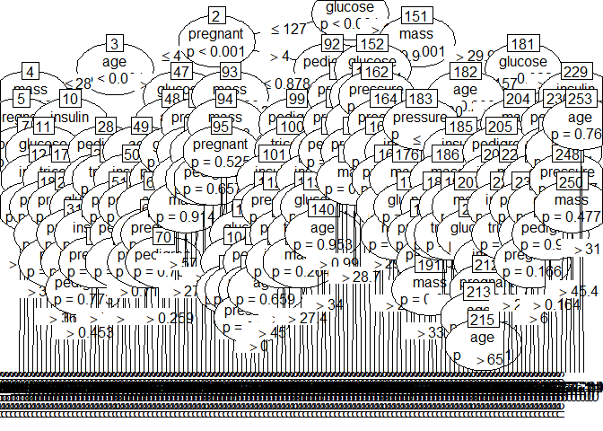

```r
diab_model <- ctree(diabetes ~ ., diab_train, control = ctree_control(mincriterion=0.005, minsplit=0, minbucket=0))
plot(diab_model)
```

```r
pred_diab_train <- predict(diab_model, diab_train)
confusionMatrix(pred_diab_train, diab_train[,9])
```

```
## Confusion Matrix and Statistics
##
##           Reference
## Prediction neg pos
##        neg 440   1
##        pos   6 244
##
##                Accuracy : 0.9899
##                  95% CI : (0.9792, 0.9959)
##     No Information Rate : 0.6454
##     P-Value [Acc > NIR] : <2e-16
##
##                   Kappa : 0.978
##  Mcnemar's Test P-Value : 0.1306
##
##             Sensitivity : 0.9865
##             Specificity : 0.9959
##          Pos Pred Value : 0.9977
##          Neg Pred Value : 0.9760
##              Prevalence : 0.6454
##          Detection Rate : 0.6368
##    Detection Prevalence : 0.6382
##       Balanced Accuracy : 0.9912
##
##        'Positive' Class : neg
##
```

```r
pred_diab_tes <- predict(diab_model, diab_test)
confusionMatrix(pred_diab_tes, diab_test[,9])
```

```
## Confusion Matrix and Statistics
##
##           Reference
## Prediction neg pos
##        neg  38   5
##        pos  16  18
##
##                Accuracy : 0.7273
##                  95% CI : (0.6138, 0.8226)
##     No Information Rate : 0.7013
##     P-Value [Acc > NIR] : 0.3600
##
##                   Kappa : 0.4276
##  Mcnemar's Test P-Value : 0.0291
##
##             Sensitivity : 0.7037
##             Specificity : 0.7826
##          Pos Pred Value : 0.8837
##          Neg Pred Value : 0.5294
##              Prevalence : 0.7013
##          Detection Rate : 0.4935
##    Detection Prevalence : 0.5584
##       Balanced Accuracy : 0.7432
##
##        'Positive' Class : neg
##
```

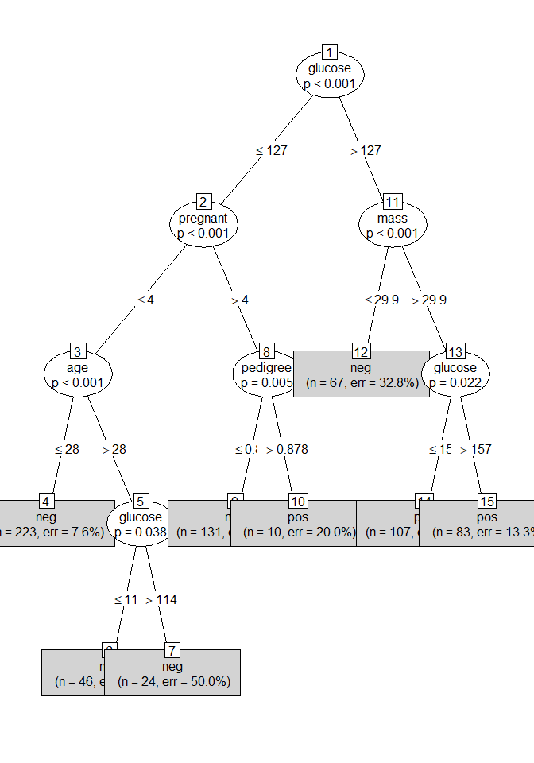

```r
temp_model <- ctree(diabetes ~ ., diab_train, control = ctree_control(mincriterion=0.95, minsplit=0, minbucket=0))
plot(temp_model, type = "simple")
```

prediksi model dengan tuning paramter mincriterion = 0.95, minsplit = 0 , minbucket = 0.

```r
pred_temp_train <- predict(temp_model, newdata = diab_train)
pred_temp_test <- predict(temp_model, newdata = diab_test)
```

```r
confusionMatrix(pred_temp_train, diab_train[,9])
```

```
## Confusion Matrix and Statistics
##
##           Reference
## Prediction neg pos
##        neg 393  98
##        pos  53 147
##
##                Accuracy : 0.7815
##                  95% CI : (0.7488, 0.8118)
##     No Information Rate : 0.6454
##     P-Value [Acc > NIR] : 5.699e-15
##
##                   Kappa : 0.5019
##  Mcnemar's Test P-Value : 0.0003427
##
##             Sensitivity : 0.8812
##             Specificity : 0.6000
##          Pos Pred Value : 0.8004
##          Neg Pred Value : 0.7350
##              Prevalence : 0.6454
##          Detection Rate : 0.5687
##    Detection Prevalence : 0.7106
##       Balanced Accuracy : 0.7406
##
##        'Positive' Class : neg
##
```

```r
confusionMatrix(pred_temp_test, diab_test[,9])
```

```
## Confusion Matrix and Statistics
##
##           Reference
## Prediction neg pos
##        neg  47  11
##        pos   7  12
##
##                Accuracy : 0.7662
##                  95% CI : (0.6559, 0.8552)
##     No Information Rate : 0.7013
##     P-Value [Acc > NIR] : 0.1301
##
##                   Kappa : 0.4127
##  Mcnemar's Test P-Value : 0.4795
##
##             Sensitivity : 0.8704
##             Specificity : 0.5217
##          Pos Pred Value : 0.8103
##          Neg Pred Value : 0.6316
##              Prevalence : 0.7013
##          Detection Rate : 0.6104
##    Detection Prevalence : 0.7532
##       Balanced Accuracy : 0.6961
##
##        'Positive' Class : neg
##
```

# Random Forest

```r
fb <- read.csv("data_input/fitbit.csv", stringsAsFactors = F)
fb[,c("user_name", "new_window", "classe")] <- lapply(fb[,c("user_name", "new_window", "classe")], as.factor)
summary(fb$classe)
```

```
##    1    2    3    4    5
## 5580 3797 3422 3216 3607
```

```r
library(caret)
set.seed(100)
n0_var <- nearZeroVar(fb[,2:158])
fb <- fb[,-n0_var]


fb_intrain <- sample(nrow(fb), nrow(fb)*0.8)
fb_train <- fb[fb_intrain, ]
fb_test <- fb[-fb_intrain, ]
```

```r
prop.table(table(fb_train$classe))
```

```
##
##         1         2         3         4         5
## 0.2852137 0.1918201 0.1746831 0.1628337 0.1854494
```

```r
prop.table(table(fb_test$classe))
```

```
##
##         1         2         3         4         5
## 0.2810191 0.2002548 0.1732484 0.1681529 0.1773248
```

```r
# set.seed(417)
# ctrl <- trainControl(method="repeatedcv", number=5, repeats=3)
# fb_forest <- train(classe ~ ., data=fb_train, method="rf", trControl = ctrl)
```

```r
fb_forest <-readRDS("fb_forest.RDS")
fb_forest
```

```
## Random Forest
##
## 15697 samples
##    56 predictor
##     5 classes: '1', '2', '3', '4', '5'
##
## No pre-processing
## Resampling: Cross-Validated (5 fold, repeated 3 times)
## Summary of sample sizes: 12555, 12558, 12559, 12558, 12558, 12557, ...
## Resampling results across tuning parameters:
##
##   mtry  Accuracy   Kappa
##    2    0.9954557  0.9942502
##   31    0.9990232  0.9987642
##   60    0.9980464  0.9975282
##
## Accuracy was used to select the optimal model using the largest value.
## The final value used for the model was mtry = 31.
```

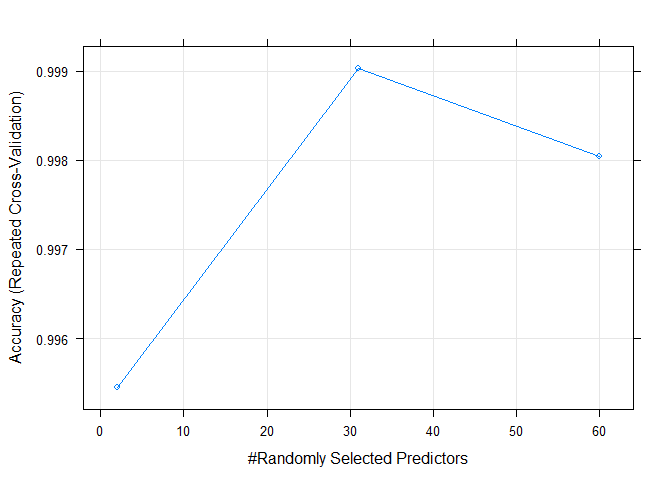

```r
plot(fb_forest)
```

```r
table(predict(fb_forest, fb_test[,-57]), fb_test[,57])
```

```
##
##        1    2    3    4    5
##   1 1103    1    0    0    0
##   2    0  785    0    0    0
##   3    0    0  680    0    0
##   4    0    0    0  660    0
##   5    0    0    0    0  696
```

```r
sum(predict(fb_forest, fb_test[,-57])==fb_test[,57])
```

```
## [1] 3924
```

```r
nrow(fb_test)
```

```
## [1] 3925
```

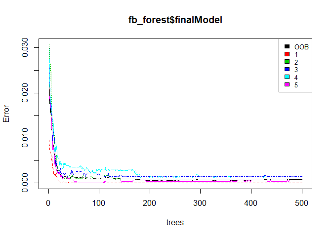

```r
plot(fb_forest$finalModel)
legend("topright", colnames(fb_forest$finalModel$err.rate),col=1:6,cex=0.8,fill=1:6)
```

```r
fb_forest$finalModel
```

```
##
## Call:
##  randomForest(x = x, y = y, mtry = param$mtry)
##                Type of random forest: classification
##                      Number of trees: 500
## No. of variables tried at each split: 31
##
##         OOB estimate of  error rate: 0.08%
## Confusion matrix:
##      1    2    3    4    5  class.error
## 1 4477    0    0    0    0 0.0000000000
## 2    1 3009    1    0    0 0.0006642312
## 3    0    4 2738    0    0 0.0014587892
## 4    0    0    3 2552    1 0.0015649452
## 5    0    0    0    2 2909 0.0006870491
```